# USA Domistic Flights Dataset for 2008

## by Manal Alkallas

## Dataset Overview

> This data set includes information about the 2008 domestic flights in the United States, including carriers, arrival and departure delays, and reasons for delays, from 1987 to 2008. The data set can be downloaded from http://stat-computing.org/dataexpo/2009/the-data.html.

### What are the main features of interest in the dataset?

- Cancelled Flights, What is the main reason behind cancelling some flights, and what is the Cancelled Flights ratio.
- Diverted Flights, What is the Diverted Flights ratio
- Delayed Flights, What is the main reason behind delaying some flights, what is the delayed flights ratio and the Percentage of Flight Delays by Day and Hour of Day
- The relationshp between Distance and AirTime

### The following features in the dataset helped support my investigation into the feature(s) of interest?

- Year', 'Month', 'DayofMonth', 'DayOfWeek', 'DepTime', 'CRSDepTime', 'ArrTime', 'AirTime', 'ArrDelay', 'DepDelay', 'Distance', ,'Cancelled', 'CancellationCode', 'Diverted', 'CarrierDelay','WeatherDelay', 'NASDelay', 'SecurityDelay', 'LateAircraftDelay'

## What is/ are the main reason/s for flight cancellation?

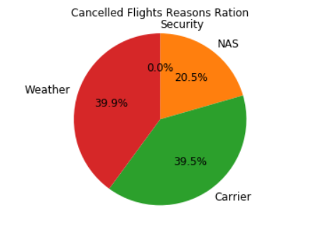

> The weather is the number one cause for flight cancellation, shortly followed by carrier. The gap in between both of them is not large but rather very close. NAS is the third highest reason for flight cancellation. No flight cancellations have been reported because of security. I assume that there is an appropriate level and standards of security. Nevertheless, weather is something out of hand.

## Which month/s occur/s more cancellation?

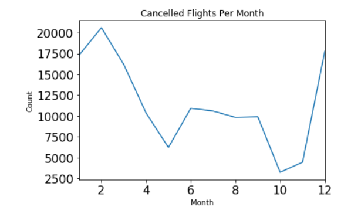

## Cancelled flights ratio

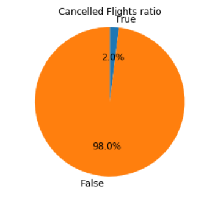

> The ratio of cancelled flights to all the flights might seem pretty low. However, in reality 2 percent of 7 million is 137434. That is a respectably high number.

## Diverted flights ratio

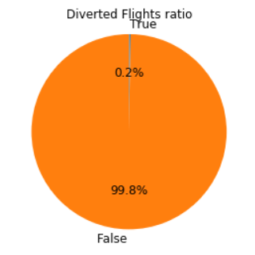

The percentage of diverted flights is much lower than the percentage of cancelled flights. 0.2 percent of 7 million is only 17,265. That is almost 8 times less than the amount of cancelled flights

## Delayed flights ratio

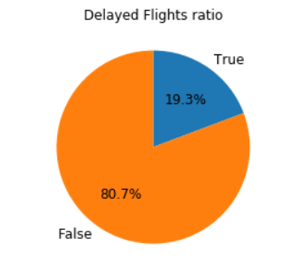

> The ratio is higher than both cancelled and diverted flights. 19.3 % is a very high number that is almost one fifth of flights being delayed.

## Is there any relation between the delayed flights and month?

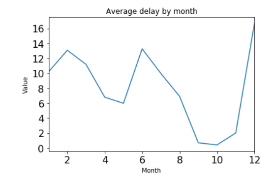

> Most delays happen in December. This is probably caused by the Christmas holidays. If we look at June and July (when the summer holidays start) it is also pretty high. However, during Christmas more people leave and travel to other states or countries. In March there is Easter that is why the number in March is also high.

## The relation between Delayed Flights and all Flights per week

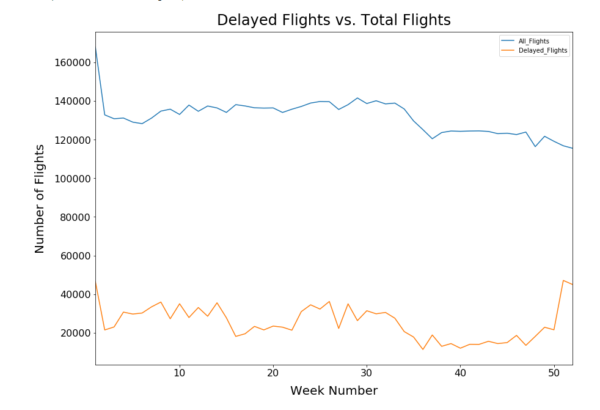

> It is clear that there is a correlation between all flights and delayed flights as expected. Unusually, the volatility in the delayed curve not present in the all-flights curve indicates that delayed flights is not a perfect function of the total number of flights.

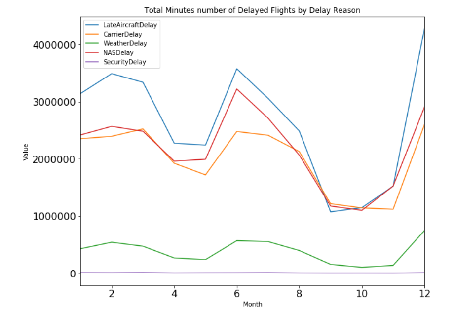

## Percentage of Flight Delays by Day and Hour of Day

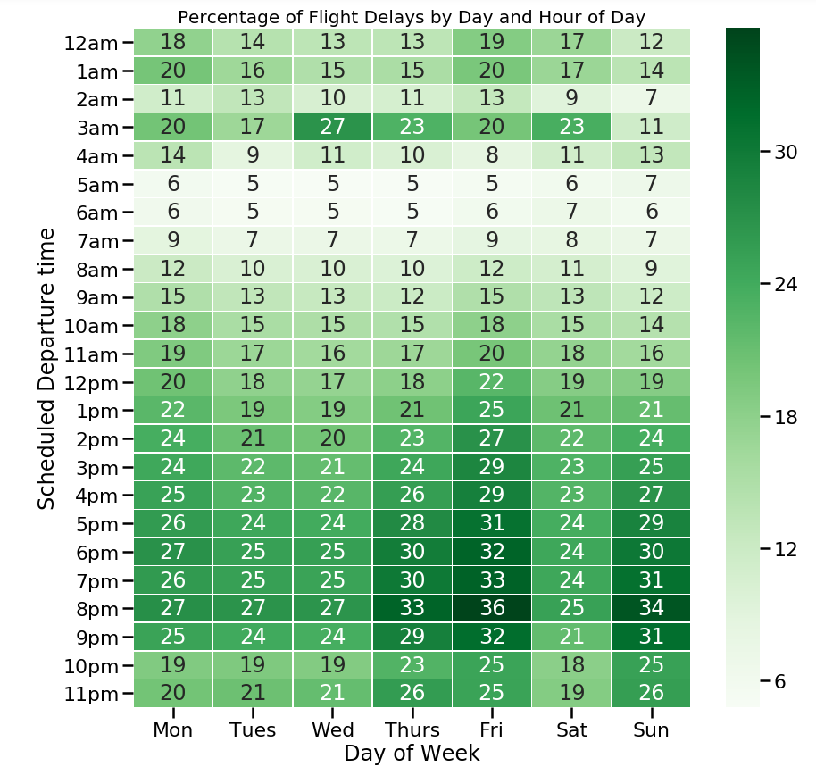

> - Flights in the afternoon and evening are more delayed than early morning and night on any day of the week
> - Flights delays are maximum on Friday and Sunday evenings at 8 pm
> - The percentage of flights delayed at 3am shows higher than normal, but that is a result of bias created by considering percentages instead of the raw numbers.

## The relation between distance and AirTime

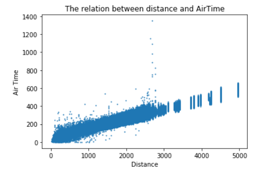

## Analyse the Distance

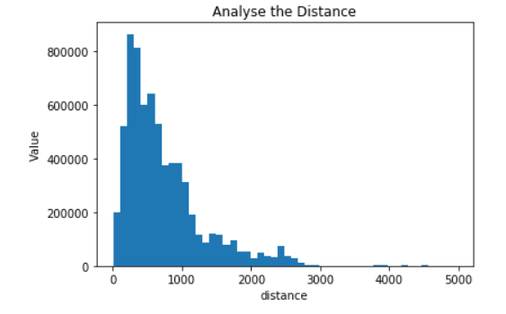

> The extremely high values should be paid more attention. These can be outliers.

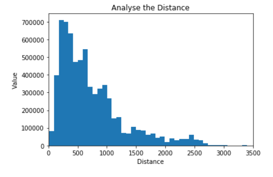

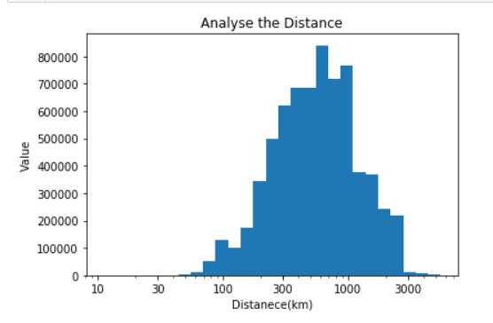

> Distance has a long-tailed distribution, with a lot of flights on the short distance end, and a few on the long-distance end. When plotted on a log-scale, the distance distribution looks roughly normal distribution with a distance ceiling at the right foot. This is simply because the longer the distance between airports is, the more limited flights there are.